# spvAPA_vignette

```r
library(spvAPA)
```

# 1. Overview

An analysis workflow using gene expression matrix and RUD matrix as input, using sPLS-DA and UMAP to perform supervised dimensionality reduction and multimodal integration of spatial transcriptome data.

# 2. Demo data

In the `spvAPA` package, we provide spatial transcriptomics data from mouse olfactory bulb sample 11 as an example dataset. It includes 260 spatial spots, which are assigned to 5 morphological layers.

```r
data("ST11GEM",package = "spvAPA")
data("ST11RUD",package = "spvAPA")
data("ST11label",package = "spvAPA")
dim(ST11GEM)
```

```
#> [1] 16218   260
```

```r
dim(ST11RUD)
```

```
#> [1] 4845  260
```

# 3. The imputation of the RUD matrix.

WNNimpute() identifies the nearest neighbor cells based on the RUD and gene expression matrices, and then performs iterative imputation using mean filling.

```r
RUD_imp <- WNNImpute(gene = ST11GEM,APA = ST11RUD,k = 15,init = F,is.weight = F)
```

[output not shown]

[output cut: 38 more lines]

[output not shown]

# 4. sPLS-DA Supervised Analysis

## 4.1 sPLS-DA on RUD matrix

The sPLS-DA calculation is implemented through the mixOmics package, which can directly obtain the optimal number of principal components and the number of genes constituting the principal components; the tutorial of model construction can be found in Section 5 of the [mixOmics](https://mixomicsteam.github.io/mixOmics-Vignette) website.

Input: (1) A matrix with rows representing cell/spot barcodes and columns representing genes or other factors; (2) Labels corresponding to cell types or morphological layer for each barcode.

```r
RUD_imp_t <- t(RUD_imp)
layer <- ST11label$label
list.keepX <- c(1:10,  seq(20, 150, 10))
RUD_spls <- sPLSDA(X = RUD_imp_t,Y = layer,ncomp = 4,KeepX = list.keepX,folds = 10,invisible = F,nCore = 12)
```

## 4.2 sPLS-DA on gene expression matrix

```r
GEM_t <- t(ST11GEM)
layer <- ST11label$label
list.keepX <- c(1:10,  seq(20, 150, 10))
GEM_spls <- sPLSDA(X = GEM_t,Y = layer,ncomp = 4,KeepX = list.keepX,folds = 10,invisible = F,nCore = 12)
```

## 4.3 Select stable genes (variable selection)

During the repeated cross-validation process in `perf()` we can record how often the same variables are selected across the folds. We select genes with a selection frequency greater than 0.9 as stable feature genes.

```r
library(org.Mm.eg.db)
RUD_perf <- RUD_spls[[3]]
featureSelect(perf = RUD_perf,stable = 0.9)
```

```
#>     comp    gene stable
#> 1  comp1  Trim16   0.96
#> 2  comp2  Nudt17   0.91
#> 3  comp3   Enpp6   1.00
#> 4  comp3  Ccdc40   0.98
#> 5  comp3 Ranbp3l   0.98
#> 6  comp3  Trim27   0.98
#> 7  comp3  Rassf8   0.97
#> 8  comp3 Map3k12   0.92
#> 9  comp4   Agbl4   1.00
#> 10 comp4  Alkbh4   1.00
#> 11 comp4   Arl5b   1.00
#> 12 comp4 Cacna1b   1.00
#> 13 comp4    Carf   1.00
#> 14 comp4    Dda1   1.00
```

[output cut: 40 more lines]

# 5. visualisation

## 5.1 Spatial distribution of component scores

Each component could be considered as a meta-gene, and the overall score of each meta-gene is a linear combination of the APA features of the corresponding component. We demonstrated the representation of the principal components in the original spatial coordinates.

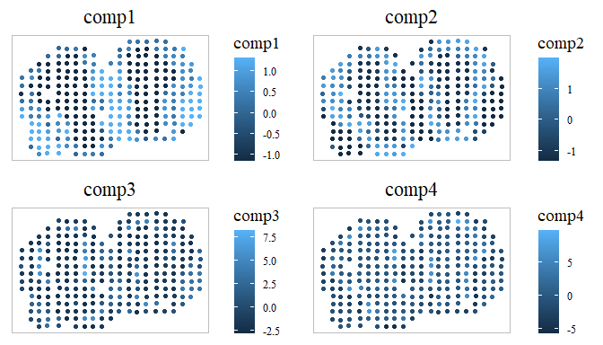

```r
# Obtain the score matrix of components.
RUD_mod <- RUD_spls[[2]]
comp_score <- as.data.frame(RUD_mod$variates$X)

# Plot

library(cowplot)

comp_score_plot <- PlotComppos(sPLS = RUD_mod,label = ST11label,comps = "ALL",size = 1.5)
plot_grid(plotlist = comp_score_plot, align = "hv")
```

## 5.2 2D Visualization

### 5.2.1 Supervised Dimensionality Reduction Visualization for Single Modality

sPLS-DA generates multiple principal components, each containing additional information to distinguish the categories of interest. To capture data patterns arising from multiple known sources of variance, we assume that multiple principal components can be used as inputs for unsupervised dimensionality reduction methods.We performed supervised dimensionality reduction on the gene expression matrix and the RUD matrix using sPLS-DA, and used the principal components from sPLS-DA as feature inputs for UMAP to generate sPLS-DA-UMAP embeddings that effectively separate the categories.

#### RUD

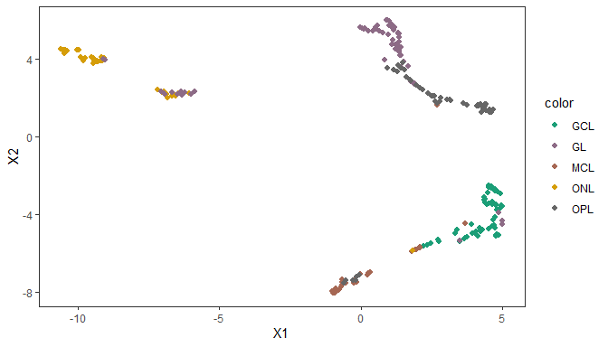

```r
PlotCompumap(spls = RUD_mod,size = 1.7)
```

#### Gene expression matrix

[figure not shown]

```r
GEM_mod <- GEM_spls[[2]]
PlotCompumap(spls = RUD_mod,size = 1.7)
```

### 5.2.2 Supervised Dimensionality Reduction Visualization Integrating Multimodal Information

Given that the sPLS-DA-UMAP embedding can separate categories within each label, we tested whether a combined approach for dimensionality reduction could be utilized to visualize gene expression and RUD in a single biplot. We combined the sPLS-DA-UMAP results from two separate sPLS-DA analyses of gene expression and RUD into a single table and used this as the feature set input for UMAP, generating a combined sPLS-DA-UMAP embedding. The resulting biplot preserved biologically meaningful patterns and achieved better intra-class cohesion and inter-class separation.

Compared to the single-modality visualization of the gene expression matrix and the RUD matrix, the two-dimensional visualization combining principal components from both modalities achieved better separation of class labels, successfully distinguishing the GL layer from the OPL layer.

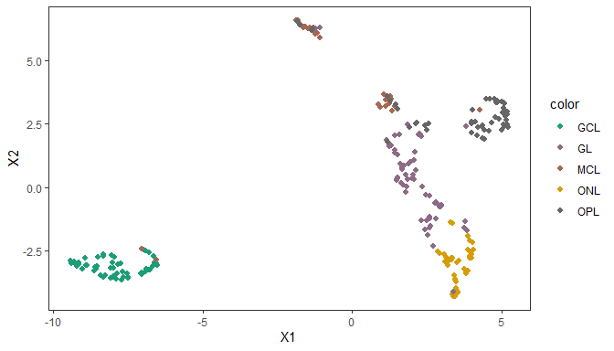

```r
PlotCompumap(spls = list(RUD_mod,GEM_mod),size = 1.7)
```